# The Sentimen Evaluation of Customer Review in Las Vegas City Restaurants

Pozy Pakya  
October 22, 2015

### Introduction

The evaluation is about the sentiment analysis over the review and stars rating restaurant in the Last Vegas city.. The YELP dataset is very resourceful which provides the valuation criteria over 61,184 unique records for business , 1,569,264 records for review and 495,107 records for the tips. Two tables have been discarded for now ,which is user details and the check-in information.The GPS longitude and latitude available inside the business dataset which provides very useful information about its geolocation. The star value gives the feedback from the customer which might be positive , negative or neutral..This will tackle some of the questions such as 1) What is the emotion type that might contain inside the review and tips messages ? 2) What is the most frequent words or terms inside it ? 3) What is the impact to the ratings by negative , neutral or neutral polarity ?

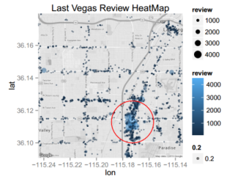

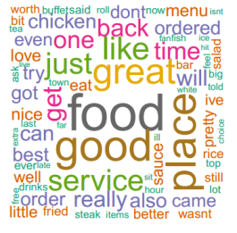

### Methods and Data

The dataset is obtained from the YELP website and extracted. The format for the dataset is in JSON . JSON need special techniques to parse and read from it. Apache Hive is the best component which is capable read this format. Since the dataset required to have a good machine in term of CPU and memory , we push this dataset to work inside Hadoop which Map-Reduce can be used as the framework for the filtering and cleaning over large size of the dataset. Hive is compatible to use scripting parameter similar to SQL and this is very suitable for speed up the entire development work. Hive also support for the complex data type and STRUCT is used to handle the JSON complex type for the table creation inside Hive . All the reviews and tips messages is filtered by removing the numbers,symbols and unnecessary spaces using R. A Naive Bayes algorithm classifies each review message into subjectivity and polarity from the input. A subjectivity indicates the words are strongly or weakly subjective and the polarity indicates the weather the words are expressing a positive , negative or neutral sentiment.

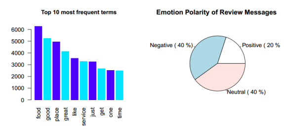

### Results

The results from the analysis we can summarize by plotting the `heatmap` of the message size inside the map of Las Vegas restaurant. We concluded that the message is more focus in the area of `Fountains of Bellagio` along the `S Las Vegas Blvd` road. This road is the main highway in Las Vegas and there is a lot of casinos along it.The red area is the central area of the review messages. Major comments all over the year since 2004 is focused in that area. The location seems very strategic and it is only 2.5 miles from the `McCarran International Airport`. Most people will stay in this area and enjoyed the food before they have their flight or after they arrive here.

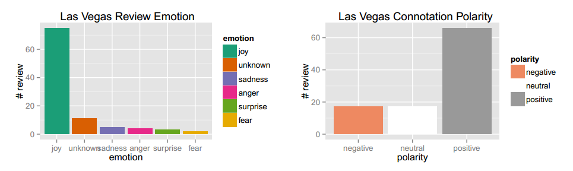

### Discussion

The issue of using such real data in this situation raises several significant questions such as :-

- How to determine the extent of limited demographic information, data frequency, the privacy concerns of Yelp users and `harsh` message that might be censored by YELP administration.
- Accessing and processing method due to increasingly for larger datasets. Some algorithm like `Random Forest` required high iteration and processing.
- Assuring a sample's diversity by implementing feature selection and optimal ratio selection for training and testing dataset for prediction in the future.
- Authentication or validation of the reviewer's identity, to reduce or eliminate bias in the reviewer comments so all the information is genuinely entered and the analysis result can be trusted.